# PS9_JTung

Tung, Joanna

March 9, 2017

```r
knitr::opts_chunk$set(warning=FALSE, message=FALSE)
```

IMPORT Packages!

```r
library(tidyverse)
library(forcats)
library(broom)
library(modelr)
library(stringr)
library(ISLR)
library(pROC)
library(grid)
library(gridExtra)
library(FNN)
library(kknn)
library(gbm)
library(ggdendro)
library(tree)
library(randomForest)
library(e1071)
```

```r
# Create function mse to calculate the mean squared error
mse <- function(model, data) {
  x <- modelr:::residuals(model, data)
  mean(x ^ 2, na.rm = TRUE)
}

# create function to calculate tree/classification test error
err.rate.tree <- function(model, data) {
  data <- as_tibble(data)
  response <- as.character(model$terms[[2]])

  pred <- predict(model, newdata = data, type = "class")
  actual <- data[[response]]

  return(mean(pred != actual, na.rm = TRUE))
}
```

PART ONE: Attitudes towards feminists

1. Split the data into a training and test set (70/30%).

Import the data

```r
fem <- read_csv("data/feminist.csv") %>%
  na.omit
```

Split the data into the training/test set partitions

```r
# set the random seed
set.seed(1234)

# Split feminist data into test/training set partition
fem_split <- resample_partition(fem, c(test = 0.3, train = 0.7))
fem_train <- fem_split$train %>%
  tbl_df()
fem_test <- fem_split$test %>%
  tbl_df()
```

2. Calculate the test MSE for KNN models with K=5,10,15,.,100, using whatever combination of variables you see fit. Which model produces the lowest test MSE?

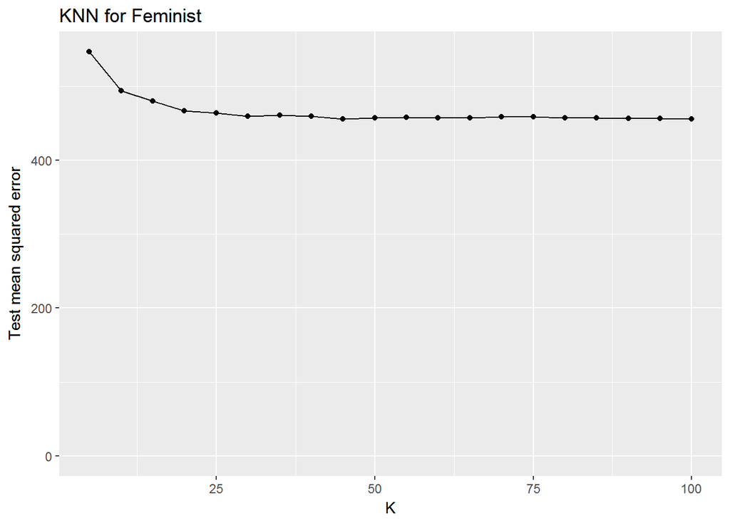

```r
# calculate the test mse for different k values
fem_mse1_knn <- data_frame(k = c(seq(5, 100, by = 5)),
                      knn = map(k, ~ knn.reg(select(fem_train, -feminist), y = fem_train$feminist,
                         test = select(fem_test, -feminist), k = .)),
                      mse = map_dbl(knn, ~ mean((fem_test$feminist - .$pred)^2)))

# plot the results
ggplot(fem_mse1_knn, aes(k, mse)) +
  geom_line() +
  geom_point() +
  labs(title = "KNN for Feminist",
       x = "K",
       y = "Test mean squared error") +
  expand_limits(y = 0)
```

```r
# view the calculated test mse values
fem_mse1_knn$mse
```

```
##  [1] 546.9755 493.8420 480.0165 466.7502 463.6671 459.2396 461.1312
##  [8] 459.5793 455.7123 457.2871 457.7437 457.5016 457.5636 458.7949
## [15] 459.1128 457.4027 457.2196 456.9237 456.9098 456.0094
```

3. Calculate the test MSE for weighted KNN models with K = 5, 10, 15, ., 100 using the same combination of variables as before. Which model produces the lowest test MSE?

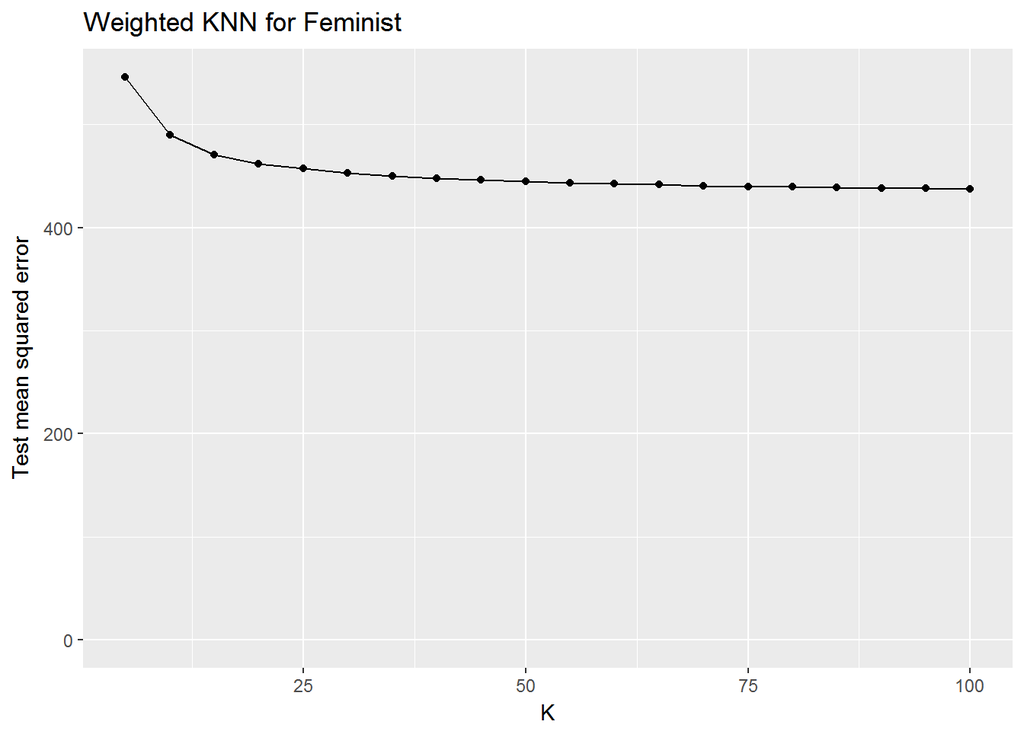

```r
# calculate the test mse for different k values
fem_mse2_knn <- data_frame(k = c(seq(5, 100, by = 5)),
                      knn = map(k, ~ kknn(feminist ~ .,
                                          train = fem_train, test = fem_test, k = .)),
                      mse = map_dbl(knn, ~ mean((fem_test$feminist - .$fitted.values)^2)))

# plot the results
ggplot(fem_mse2_knn, aes(k, mse)) +
  geom_line() +
  geom_point() +
  labs(title = "Weighted KNN for Feminist",
       x = "K",
       y = "Test mean squared error") +
  expand_limits(y = 0)
```

```r
# view the calculated test mse values
fem_mse2_knn
```

```
## # A tibble: 20 × 3
##        k        knn      mse
##    <dbl>     <list>    <dbl>
## 1      5 <S3: kknn> 546.1298
## 2     10 <S3: kknn> 489.6123
## 3     15 <S3: kknn> 470.6933
## 4     20 <S3: kknn> 462.0196
## 5     25 <S3: kknn> 457.3337
## 6     30 <S3: kknn> 452.5241
## 7     35 <S3: kknn> 449.6870
## 8     40 <S3: kknn> 447.5103
## 9     45 <S3: kknn> 445.9645
## 10    50 <S3: kknn> 444.7194
## 11    55 <S3: kknn> 443.4669
## 12    60 <S3: kknn> 442.4137
## 13    65 <S3: kknn> 441.4353
## 14    70 <S3: kknn> 440.5221
## 15    75 <S3: kknn> 439.6563
## 16    80 <S3: kknn> 439.1449
## 17    85 <S3: kknn> 438.5183
## 18    90 <S3: kknn> 438.0937
## 19    95 <S3: kknn> 437.6844
## 20   100 <S3: kknn> 437.3657
```

4. Compare the test MSE for the best KNN/wKNN model(s) to the test MSE for the equivalent linear regression, decision tree, boosting, and random forest methods using the same combination of variables as before. Which performs the best? Why do you think this method performed the best, given your knowledge of how it works

Using the test MSE as our indicator, of the models run below, the Boosting mdethod with interaction depth 4 and trees = 1302 “performed the best” with the lowest test MSE of 432.5293. This is perhaps not entirely unsurprising because the boosting method works to iteratively reduce residual with every new tree. Since test MSE grows with increasing magnitude of residuals, boosting is a naturally good approach for reducing test MSE.

```r
# create dataframe of results
P1_4_results <- data_frame(Model = c("KNN", "WKNN", "Linear Regression", "Decision Tree", "Boosting", "Random Forest"),
                           Specs = c("k = 45", "k = 100", "N/A", "Pruned with Terminal Nodes = 3", "Interaction Depth = 4, No. of Trees = 1302", "No. of Trees = 1000"),
                           Test_MSE = c(455.7123, 437.3657, 435.1107, 436.1426, 432.5293, 437.925)) %>%
  arrange((Test_MSE))

# print table of results
library(knitr)
kable(P1_4_results)
```

| Model | Specs | Test_MSE |
| --- | --- | --- |
| Boosting | Interaction Depth = 4, No. of Trees = 1302 | 432.5293 |
| Linear Regression | N/A | 435.1107 |
| Decision Tree | Pruned with Terminal Nodes = 3 | 436.1426 |
| WKNN | k = 100 | 437.3657 |
| Random Forest | No. of Trees = 1000 | 437.9250 |
| KNN | k = 45 | 455.7123 |

```r
# compare to linear regression
fem_lm <- lm(feminist ~ ., data = fem_split$train)
fem_mse_lm <- mse(fem_lm, fem_split$test)

fem_mse_lm
```

```
## [1] 435.1107
```

```r
summary(fem_lm)
```

```
##
## Call:
## lm(formula = feminist ~ ., data = fem_split$train)
##
## Residuals:
##     Min      1Q  Median      3Q     Max
## -66.834 -10.820  -2.065  11.484  52.825
##
## Coefficients:
##              Estimate Std. Error t value Pr(>|t|)
## (Intercept) 52.381200   3.774772  13.877  < 2e-16 ***
## female       6.183232   1.205850   5.128 3.39e-07 ***
## age         -0.007772   0.035868  -0.217 0.828484
## educ         0.172570   0.258506   0.668 0.504530
## income      -0.147707   0.109635  -1.347 0.178137
## dem          7.070944   1.306056   5.414 7.36e-08 ***
## rep         -6.005882   1.636477  -3.670 0.000253 ***
## ---
## Signif. codes:  0 '***' 0.001 '**' 0.01 '*' 0.05 '.' 0.1 ' ' 1
##
## Residual standard error: 20.64 on 1270 degrees of freedom
## Multiple R-squared:  0.0846, Adjusted R-squared:  0.08027
## F-statistic: 19.56 on 6 and 1270 DF,  p-value: < 2.2e-16
```

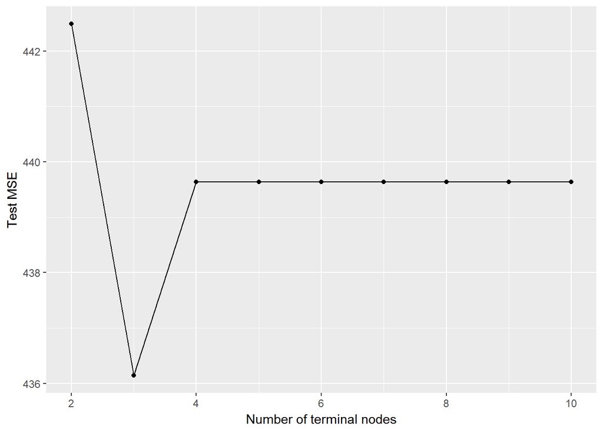

```r
# compare to decision tree

# set the random seed
set.seed(1234)

# generate 10-fold CV trees
fem_cv <- crossv_kfold(fem, k = 10) %>%
  mutate(tree = map(train, ~ tree(feminist ~ ., data = .)))

# calculate each possible prune result for each fold
fem_cv2 <- expand.grid(fem_cv$.id, 2:10) %>%
  as_tibble() %>%
  mutate(Var2 = as.numeric(Var2)) %>%
  rename(.id = Var1,
         k = Var2) %>%
  left_join(fem_cv) %>%
  mutate(prune = map2(tree, k, ~ prune.tree(.x, best = .y)),
         mse = map2_dbl(prune, test, mse))

# plot the results
fem_mse <- fem_cv2 %>%
  select(k, mse) %>%
  group_by(k) %>%
  summarize(test_mse = mean(mse),
            sd = sd(mse, na.rm = TRUE))

fem_mse_plot <- fem_mse %>%
  ggplot(aes(k, test_mse)) +
  geom_point() +
  geom_line() +
  labs(x = "Number of terminal nodes",
       y = "Test MSE")
fem_mse_plot
```

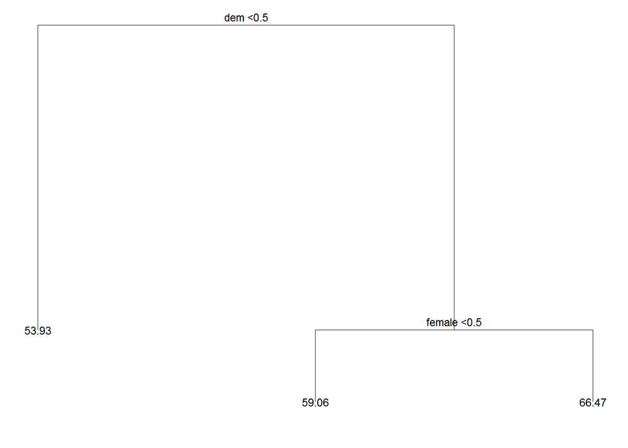

```r
# Select smallest terminal nodes (=3 from plot above) and create the final DT
# generate tree model
fem_DT <- tree(feminist ~ ., data = fem_split$train)

# prune the model using terminal nodes = 3
mod_fem_DT <- prune.tree(fem_DT, best = 3)

# plot the tree
pfem_DT <- dendro_data(mod_fem_DT)
ptree_fem <- ggplot(segment(pfem_DT)) +
  geom_segment(aes(x = x, y = y, xend = xend, yend = yend),
               alpha = 0.5) +
  geom_text(data = label(pfem_DT),
            aes(x = x, y = y, label = label_full), vjust = -0.5, size = 3) +
  geom_text(data = leaf_label(pfem_DT),
            aes(x = x, y = y, label = label), vjust = 0.5, size = 3) +
  theme_dendro()

ptree_fem
```

```r
fem_mse
```

```
## # A tibble: 9 × 3
##       k test_mse       sd
##   <dbl>    <dbl>    <dbl>
## 1     2 442.4877 40.37892
## 2     3 436.1426 41.13215
## 3     4 439.6337 44.06795
## 4     5 439.6337 44.06795
## 5     6 439.6337 44.06795
## 6     7 439.6337 44.06795
## 7     8 439.6337 44.06795
## 8     9 439.6337 44.06795
## 9    10 439.6337 44.06795
```

```r
# compare to the boosting method, part one

# set random seed
set.seed(1234)

# run multiple models
fem_boost_testmodels <- list("boosting_depth1" = gbm(feminist ~ .,
                                               data = fem_split$train,
                                               n.trees = 5000, interaction.depth = 1),
                       "boosting_depth2" = gbm(feminist ~ .,
                                               data = fem_split$train,
                                               n.trees = 5000, interaction.depth = 2),
                       "boosting_depth4" = gbm(feminist ~ .,
                                               data = fem_split$train,
                                               n.trees = 5000, interaction.depth = 4),
                       "boosting_depth10" = gbm(feminist ~ .,
                                               data = fem_split$train,
                                               n.trees = 5000, interaction.depth = 10))
```

```
## Distribution not specified, assuming gaussian ...
## Distribution not specified, assuming gaussian ...
## Distribution not specified, assuming gaussian ...
## Distribution not specified, assuming gaussian ...
```

```r
data_frame(depth = c(1, 2, 4, 10),
           model = fem_boost_testmodels[c("boosting_depth1", "boosting_depth2", "boosting_depth4", "boosting_depth10")],
           optimal = map_dbl(model, gbm.perf, plot.it = FALSE))
```

```
## Using OOB method...
## Using OOB method...
## Using OOB method...
## Using OOB method...
```

```
## # A tibble: 4 × 3
##   depth     model optimal
##   <dbl>    <list>   <dbl>
## 1     1 <S3: gbm>    2291
## 2     2 <S3: gbm>    1689
## 3     4 <S3: gbm>    1343
## 4    10 <S3: gbm>     960
```

```r
# compare to the boosting method, part two

# set random seed
set.seed(1234)

# run the models with the optimal number of trees
fem_boost_models <- list("boosting_depth1" = gbm(feminist ~ .,
                                               data = fem_split$train,
                                               n.trees = 2294, interaction.depth = 1),
                       "boosting_depth2" = gbm(feminist ~ .,
                                               data = fem_split$train,
                                               n.trees = 1692, interaction.depth = 2),
                       "boosting_depth4" = gbm(feminist ~ .,
                                               data = fem_split$train,
                                               n.trees = 1302, interaction.depth = 4),
                       "boosting_depth10" = gbm(feminist ~ .,
                                               data = fem_split$train,
                                               n.trees = 974, interaction.depth = 10))
```

```
## Distribution not specified, assuming gaussian ...
## Distribution not specified, assuming gaussian ...
## Distribution not specified, assuming gaussian ...
## Distribution not specified, assuming gaussian ...
```

```r
# get predictions for the different models using the test data
boost1_pred <- predict(fem_boost_models$boosting_depth1,
                       newdata = as_tibble(fem_split$test),
                       n.trees = 2294)
boost2_pred <- predict(fem_boost_models$boosting_depth2,
                       newdata = as_tibble(fem_split$test),
                       n.trees = 1692)
boost4_pred <- predict(fem_boost_models$boosting_depth4,
                       newdata = as_tibble(fem_split$test),
                       n.trees = 1302)
boost10_pred <- predict(fem_boost_models$boosting_depth10,
                       newdata = as_tibble(fem_split$test),
                       n.trees = 974)

# print the MSE for the test set
boost1_mse <- mean((boost1_pred - fem_test$feminist)^2)
boost1_mse
```

```
## [1] 434.3285
```

```r
boost2_mse <- mean((boost2_pred - fem_test$feminist)^2)
boost2_mse
```

```
## [1] 432.6693
```

```r
boost4_mse <- mean((boost4_pred - fem_test$feminist)^2)
boost4_mse
```

```
## [1] 432.5293
```

```r
boost10_mse <- mean((boost10_pred - fem_test$feminist)^2)
boost10_mse
```

```
## [1] 432.7522
```

```r
# compare to the random Forest method

# set the seed
set.seed(1234)

# perform bagging on the training set
fem_rf <- randomForest(feminist ~ ., data = fem_split$train, ntree = 1000)

# print results
print(fem_rf)
```

```
##
## Call:
##  randomForest(formula = feminist ~ ., data = fem_split$train,      ntree = 1000)
##                Type of random forest: regression
##                      Number of trees: 1000
## No. of variables tried at each split: 2
##
##           Mean of squared residuals: 440.0374
##                     % Var explained: 4.9
```

```r
# calculate error
femrf_err <- mse(fem_rf, fem_split$test)
femrf_err
```

```
## [1] 437.925
```

PART TWO: Voter turnout and depression

1. Split the data into a training and test set (70/30).

IMPorT THE DATA!

```r
# read in the data and get rid of NAs
voter <- read_csv("data/mental_health.csv") %>%
  mutate_each(funs(as.factor(.)), vote96, black, female, married) %>%
  na.omit

voter
```

```
## # A tibble: 1,165 × 8
##    vote96 mhealth_sum   age  educ  black female married   inc10
##    <fctr>       <dbl> <dbl> <dbl> <fctr> <fctr>  <fctr>   <dbl>
## 1       1           0    60    12      0      0       0  4.8149
## 2       1           1    36    12      0      0       1  8.8273
## 3       0           7    21    13      0      0       0  1.7387
## 4       0           6    29    13      0      0       0 10.6998
## 5       1           1    41    15      1      1       1  8.8273
## 6       1           2    48    20      0      0       1  8.8273
## 7       0           9    20    12      0      1       0  7.2223
## 8       0          12    27    11      0      1       0  1.2037
## 9       1           2    28    16      0      0       1  7.2223
## 10      1           0    72    14      0      0       1  4.0124
## # ... with 1,155 more rows
```

```r
# code to test MSE's with different subset of variables
#voter <- subset(voter_data, select = -c(black,female,married, inc10))
#voter
```

```r
# set the random seed
set.seed(1234)

# Split voter data into test/training set partition
vote_split <- resample_partition(voter, c(test = 0.3, train = 0.7))
vote_train <- vote_split$train %>%
  tbl_df()
vote_test <- vote_split$test %>%
  tbl_df()
```

2. Calculate the test error rate for KNN models with K=1,2,.,10, using whatever combination of variables you see fit. Which model produces the lowest test error?

Again, because this is exploratory learning, all variables were included in the analysis. The K-nearest neighbors model with k = 3 produced the lowest test error, 0.3065903.

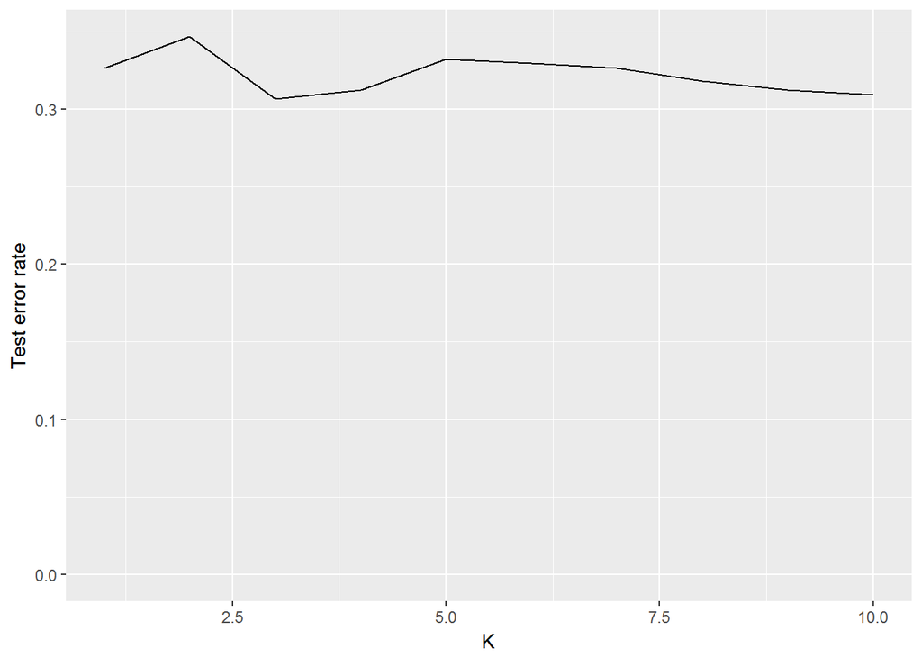

```r
# calculate the test error for different k values
vote_err1_knn <- data_frame(k = 1:10,
                            knn_train = map(k, ~ class::knn(select(vote_train, -vote96),
                                                test = select(vote_train, -vote96),
                                                cl = vote_train$vote96, k = .)),
                            knn_test = map(k, ~ class::knn(select(vote_train, -vote96),
                                                test = select(vote_test, -vote96),
                                                cl = vote_train$vote96, k = .)),
                            err_train = map_dbl(knn_train, ~ mean(vote_test$vote96 != .)),
                            err_test = map_dbl(knn_test, ~ mean(vote_test$vote96 != .)))

# plot the results
ggplot(vote_err1_knn, aes(k, err_test)) +
  geom_line() +
  labs(x = "K",
       y = "Test error rate") +
  expand_limits(y = 0)
```

```r
# view test error
vote_err1_knn$err_test
```

```
##  [1] 0.3266476 0.3467049 0.3065903 0.3123209 0.3323782 0.3295129 0.3266476
##  [8] 0.3180516 0.3123209 0.3094556
```

3. Calculate the test error rate for weighted KNN models with K=1,2,.,10 using the same combination of variables as before. Which model produces the lowest test error rate?

The weighted K-nearest neighbors model with K = 10 produced the lowest test error rate, 0.2779370.

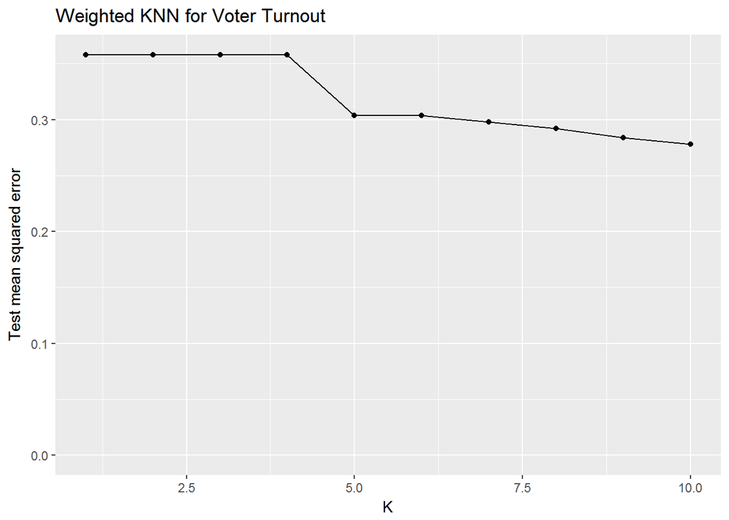

```r
# calculate the test error for different k values, with weighted KNN
vote_err2_knn <- data_frame(k = 1:10,
                            knn = map(k, ~ kknn(vote96 ~ .,
                                          train = vote_train, test = vote_test, k = .)),
                            err = map_dbl(knn, ~ mean(vote_test$vote96 != .$fitted.values)))

# plot the results
ggplot(vote_err2_knn, aes(k, err)) +
  geom_line() +
  geom_point() +
  labs(title = "Weighted KNN for Voter Turnout",
       x = "K",
       y = "Test mean squared error") +
  expand_limits(y = 0)
```

```r
# view the error
vote_err2_knn
```

```
## # A tibble: 10 × 3
##        k        knn       err
##    <int>     <list>     <dbl>
## 1      1 <S3: kknn> 0.3581662
## 2      2 <S3: kknn> 0.3581662
## 3      3 <S3: kknn> 0.3581662
## 4      4 <S3: kknn> 0.3581662
## 5      5 <S3: kknn> 0.3037249
## 6      6 <S3: kknn> 0.3037249
## 7      7 <S3: kknn> 0.2979943
## 8      8 <S3: kknn> 0.2922636
## 9      9 <S3: kknn> 0.2836676
## 10    10 <S3: kknn> 0.2779370
```

4. Compare the test error rate for the best KNN/wKNN model(s) to the test error rate for the equivalent logistic regression, decision tree, boosting, random forest, and SVM methods using the same combination of variables as before. Which performs the best? Why do you think this method performed the best, given your knowledge of how it works?